# Reproducible Research - Peer Assessment 1

Miriam P.

January 21, 2018

## Overview

This document describes an analysis done for an assignment of the Coursera Reproducible Research Course from Johns Hopkins University.

Using devices such as Jawbone Up, Nike FuelBand, and Fitbit it is now possible to collect a large amount of data about personal activity relatively inexpensively. These IoT devices are part of the quantified self movement – a group of enthusiasts who take measurements about themselves regularly to improve their health, to find patterns in their behavior, or because they are tech geeks. One thing that people regularly do is quantify how much of a particular activity they do, but they rarely quantify how well they do it.

Click on links here to quickly view tasks completed in this assignment:

1. Code for reading in the dataset and/or processing the data
2. Histogram of the total number of steps taken each day
3. Mean and median number of steps taken each day
4. Time series plot of the average number of steps taken
5. The 5-minute interval that, on average, contains the maximum number of steps
6. Code to describe and show a strategy for imputing missing data
7. Histogram of the total steps per day after missing values are imputed
8. Panel plot comparing average steps per 5-minute interval across weekdays and weekends

The data for this assignment comes from from the course web site:

- [activityData](https://d396qusza40orc.cloudfront.net/repdata%2Fdata%2Factivity.zip)

## Details

Before beginning the project, be sure to load the required R libraries and set any environmental variables. Note that setting messages in markdown to false suppresses messages from library loading such as version number and dependencies. Updating to latest versions of these libraries may improve ability to obtain results fairly similar to the steps outlined here.

```r
# Clear environment of prior calculations. For best results always create/use an R project to run this.
    rm(list=ls())
```

```r
library(data.table)
library(dplyr)
library(knitr)
library(ggplot2)
library(ggthemes)
library(Hmisc)
```

### 1. Load and Clean Data

```r
#### A.  Loading data
# set working environment
    workDataDirStr <- paste(getwd(),"/", sep="")
# Load the files. Using NA function to assure clean file
    read.activity <- function(file) {
        fread(file, na.strings=c("NA", ""))
    }
    activityData <- read.activity(paste(workDataDirStr, "activity.csv", sep=""))
```

- Dimensions of activityData (rows,columns): 17568, 3

Add any steps here to process, scale or transform the data further before analysis:

```r
#### B.  Cleaning data
# convert date string to date datatype
    activityData$date<-as.Date(activityData$date)
# Since have two libraries with wday function specify lubridate to add Weekday
    activityData$Weekday<-lubridate::wday(activityData$date, label = TRUE, abbr = FALSE)
# convert all steps to whole number
    activityData$steps<-round(activityData$steps, digits=0)
```

back to top

### 2. Make a histogram of the total number of steps taken each day

```r
# Data Exploration - What is mean total number of steps taken per day, per weekday, per interval?

#### A.  Pre-processing
# Query and convert dataset for plotting
    activityData.sums <- activityData %>%
    group_by(date,Weekday) %>%
    summarise(totalSteps = sum(steps, na.rm=TRUE))
# Get max number of steps for largest interval for extending y-axis to fit labels.
    activityData.max <- round(max(activityData.sums$totalSteps, na.rm = TRUE),digits=0)
# Get initial averaging data for histogram plot
    activityData.mean <- round(mean(activityData.sums$totalSteps, na.rm = TRUE),digits=0)
    activityData.median <- round(median(activityData.sums$totalSteps, na.rm = TRUE),digits=0)
```

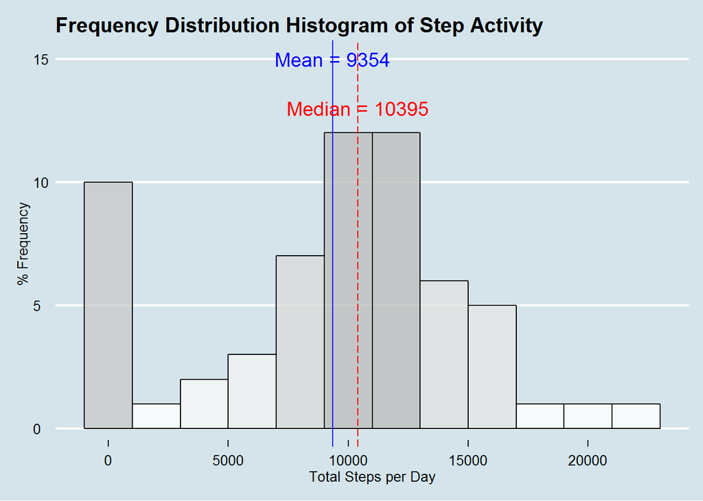

```r
#### B.  Plotting
# Prepare labels for plot
    textlab_1 <-  paste("Mean = ", activityData.mean, sep="")
    textlab_2 <-  paste("Median = ", activityData.median, sep="")
# Define and call plot
    plot_2 <- ggplot(data=activityData.sums, aes(activityData.sums$totalSteps)) +
        geom_histogram(
                 col="black",
                 aes(fill=..count..),
                 alpha = .8,
                 binwidth = 2000) +
        labs(title = "Frequency Distribution Histogram of Step Activity",
        y="% Frequency",
        x="Total Steps per Day") +
        theme_economist() +
        geom_vline(xintercept = activityData.mean, colour="blue", linetype = "solid") +
        geom_vline(xintercept = activityData.median, colour="red", linetype = "longdash") +
        annotate("text", label = textlab_1, x = activityData.mean, y = 15, size = 5, colour = "blue") +
        annotate("text", label = textlab_2, x = activityData.median, y = 13, size = 5, colour = "red") +
        theme(legend.position = "none") +
        scale_fill_gradient("Count", low = "white", high = "gray")  +
        scale_colour_economist()
    plot_2
```

back to top

### 3. Calculate and report the mean/median total steps taken per day

```r
#### A.  Calculate and Display initial daily averaging data
    dailyAvgSteps <- activityData.sums %>%
    group_by(Weekday,totalSteps) %>%
    filter(!is.na(totalSteps))

    dailyAvgSteps           #Preveview of daily average ateps
```

```
## Source: local data frame [61 x 3]
## Groups: Weekday, totalSteps [59]
##
##          date   Weekday totalSteps
##        <date>     <ord>      <dbl>
## 1  2012-10-01    Monday          0
## 2  2012-10-02   Tuesday        126
## 3  2012-10-03 Wednesday      11352
## 4  2012-10-04  Thursday      12116
## 5  2012-10-05    Friday      13294
## 6  2012-10-06  Saturday      15420
## 7  2012-10-07    Sunday      11015
## 8  2012-10-08    Monday          0
## 9  2012-10-09   Tuesday      12811
## 10 2012-10-10 Wednesday       9900
## # ... with 51 more rows
```

```r
#### B. Describe norms
    dailyAvgSteps.mean   <- round(mean(dailyAvgSteps$totalSteps, na.rm = TRUE), digits=0)
    dailyAvgSteps.mean      # Mean number of steps
```

```
## [1] 9354
```

```r
    dailyAvgSteps.median <- round(median(dailyAvgSteps$totalSteps, na.rm = TRUE), digits=0)
    dailyAvgSteps.median    # Median number of steps
```

```
## [1] 10395
```

Answer: The plot shows that the mean is lower than the median indicating a potential issue with missing data that could impact calculations on this set.

back to top

### 4. Display a time series plot

```r
#### A.  What is the average daily activity pattern?
    activityData.intervals <- activityData %>%
    group_by(interval) %>%
    filter(!is.na(steps)) %>%
    summarise(meanSteps = mean(steps, na.rm=TRUE))

    activityData.intervals   # Preview of average steps per tnterval
```

```
## # A tibble: 288 x 2
##    interval meanSteps
##       <int>     <dbl>
## 1         0 1.7169811
## 2         5 0.3396226
## 3        10 0.1320755
## 4        15 0.1509434
## 5        20 0.0754717
## 6        25 2.0943396
## 7        30 0.5283019
## 8        35 0.8679245
## 9        40 0.0000000
## 10       45 1.4716981
## # ... with 278 more rows
```

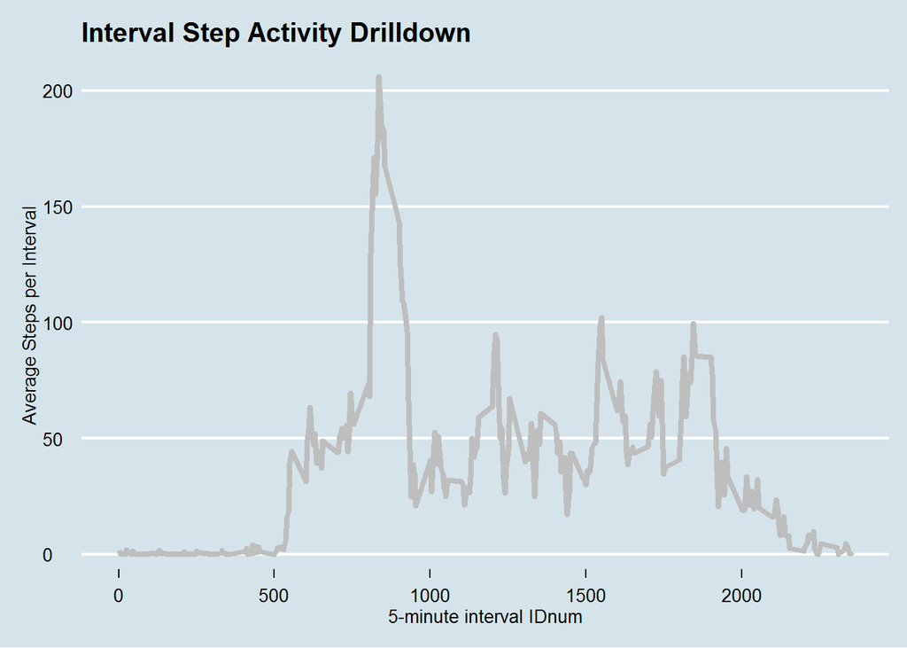

```r
#### B.  Prepare a histogram of frequency counts/percentages.
    plot_4 <- ggplot(data=activityData.intervals, aes(x=interval, y=meanSteps)) +
        geom_line(colour="gray", linetype="solid", size=1.5) +
        labs(title = "Interval Step Activity Drilldown",
             y="Average Steps per Interval",
             x="5-minute interval IDnum")+
        theme_economist() +
        scale_colour_economist()
    plot_4
```

back to top

### 5. Determine average daily maximum steps in a 5-minute interval

```r
#### A. Find the largest item in series and call related descriptive informat
    mostInt <- which.max(activityData.intervals$meanSteps)
    intervalMax <- activityData.intervals[mostInt,]
    maxIntID <- intervalMax$interval
    maxSteps <- round(intervalMax$meanSteps, digits=0)
```

Answer: The most number of steps occurred in the morning

- The number of Most Steps: 206
- Occurred at Interval ID (time of day): 835

back to top

### 6. Impute missing values

Calculate and report the total and missing values in the dataset:

```r
#### A. Calculate total number of missing values in dataset:
    numTotalValues <- length(activityData$steps)
    numMissingValues <- length(which(is.na(activityData$steps)))
```

BEFORE ADJUSTMENT

- Number of total values: 17568
- Number of missing values: 2304
- Percent Missing : 13.1147541 percent

Fill in the missing observations with mean-derived data:

```r
#### B. Impute misssing value based on daily average:
    activityData2 <- activityData
    activityData2$steps <- round(impute(activityData$steps, fun=mean), digits = 0)
    numTotalValues2 <- length(activityData2$steps)
    numMissingValues2 <- length(which(is.na(activityData2$steps)))
```

AFTER ADJUSTMENT

- Number of total values: 17568
- Number of missing values: 0

Answer: The missing values have all been filled in with the estimated ones.

back to top

### 7. Make histogram plot of total number of steps taken each day with additional data

```r
# Data Exploration - What is mean total number of steps taken per day, per weekday, per interval?

#### A.  Pre-processing
# Query and convert dataset for plotting
    activityData2.sums <- activityData2 %>%
    group_by(date,Weekday) %>%
    summarise(totalSteps = sum(steps, na.rm=TRUE))
# Get max number of steps for largest interval for extending y-axis to fit labels.
    activityData2.max <- round(max(activityData2.sums$totalSteps, na.rm = TRUE),digits=0)
# Get initial averaging data for histogram plot
    activityData2.mean <- round(mean(activityData2.sums$totalSteps, na.rm = TRUE),digits=0)
    activityData2.median <- round(median(activityData2.sums$totalSteps, na.rm = TRUE),digits=0)
```

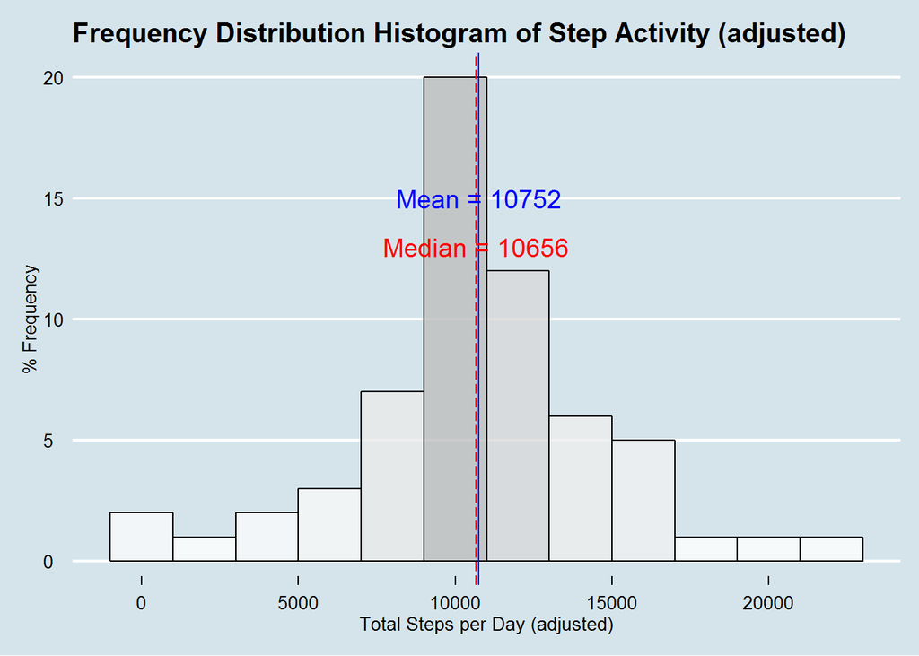

```r
#### B.  Plotting
# Prepare labels for plot
    textlab_1 <-  paste("Mean = ", activityData2.mean, sep="")
    textlab_2 <-  paste("Median = ", activityData2.median, sep="")
# Define and call plot
    plot_7 <- ggplot(data=activityData2.sums, aes(activityData2.sums$totalSteps)) +
        geom_histogram(
                 col="black",
                 aes(fill=..count..),
                 alpha = .8,
                 binwidth = 2000) +
        labs(title = "Frequency Distribution Histogram of Step Activity (adjusted)",
        y="% Frequency",
        x="Total Steps per Day (adjusted)") +
        theme_economist() +
        geom_vline(xintercept = activityData2.mean, colour="blue", linetype = "solid") +
        geom_vline(xintercept = activityData2.median, colour="red", linetype = "longdash") +
        annotate("text", label = textlab_1, x = activityData2.mean, y = 15, size = 5, colour = "blue") +
        annotate("text", label = textlab_2, x = activityData2.median, y = 13, size = 5, colour = "red") +
        #theme(legend.title=element_blank()) +
        theme(legend.position = "none") +
        #theme(text = element_text(size=12), axis.text.x = element_text(angle=90, vjust=1)) +
        scale_fill_gradient("Count", low = "white", high = "gray")  +
        #theme(legend.position=c(.7, .75)) +
        scale_colour_economist()
    plot_7
```

Calculate and report the mean and median total number of steps taken per day:

```r
##### C.  Measuring new norms and impact of differences
    activityData2.mean   <- round(mean(activityData2.sums$totalSteps, na.rm = TRUE),digits=0)
    activityData2.mean      # Mean number of steps (adjusted)
```

```
## [1] 10752
```

```r
    activityData2.median <- round(median(activityData2.sums$totalSteps, na.rm = TRUE),digits=0)
    activityData2.median    # Median number of steps (adjusted)
```

```
## [1] 10656
```

- What is potential impact on results of adding data to NAs?
  - Mean Adjusted / Mean Raw :1.1494548
  - Median Adjusted / Median Raw :1.0251082

Answer: Given that 13 percent of the raw data was empty the additional imputed values raised the mean by 14.94 percent and the median by only 2.51 percent. Now the adjusted mean and median are more similar, which was the goal of the estimation process.

back to top

### 8. Are there differences in activity patterns between weekdays and weekends?

Create a new factor variable in the dataset with two levels – “weekday” and “weekend” indicating whether a given date is a weekday or weekend day:

```r
#### A.  Transforming dataset features and splitting data

# Add new dataType field
    activityData2$dateType <-  ifelse(as.POSIXlt(activityData2$date)$wday %in% c(0,6), 'weekend', 'weekday')

# This is a shorter version of interval set creation
   activityData2Interval <- aggregate(steps ~ interval + dateType, data=activityData2, mean)
```

Make a panel plot containing a time series plot:

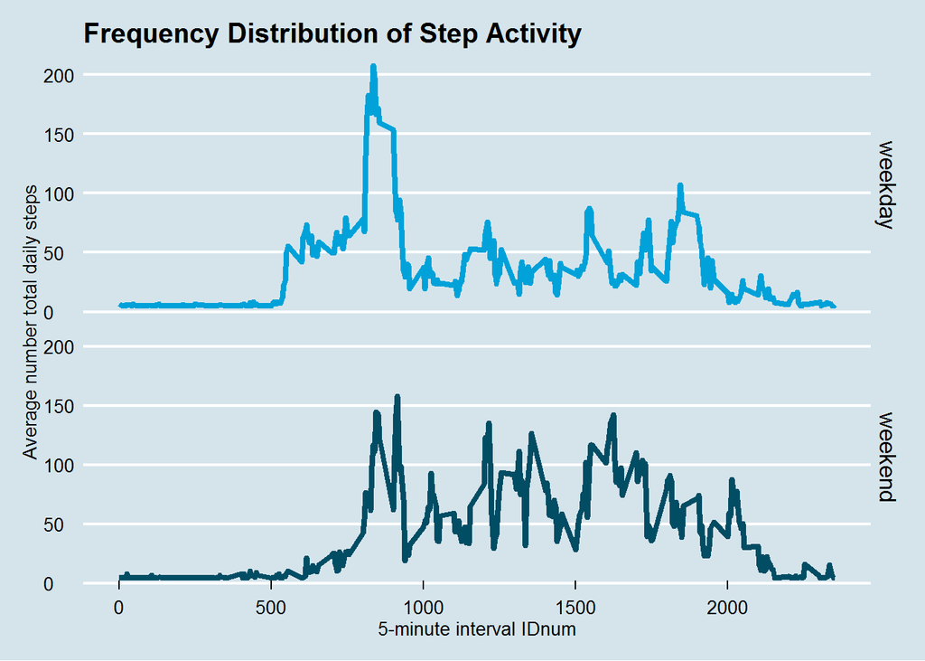

```r
#### B.  Plotting

    plot_8 <- ggplot(activityData2Interval, aes(interval, steps, colour=dateType)) +
        geom_line(linetype="solid", size=1.5) +
        facet_grid(dateType ~ .) +
        labs(title = "Frequency Distribution of Step Activity",
            x="5-minute interval IDnum",
            y="Average number total daily steps") +
        theme_economist() +
        theme(legend.position="none") +
        scale_colour_economist()
    plot_8
```

back to top

back to top